# Python数据处理

## R2 score

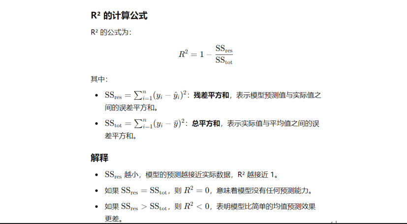

```python
# CV用于我们选择超参数，如LASSO中的alpha
from sklearn.linear_model import Lasso
from sklearn.model_selection import cross_val_score
import numpy as np
beta = np.zeros(dim)
inds = np.random.choice(np.arange(dim), size=k, replace=False)
beta[inds] = np.random.randn(k)
(n_sample, dim, k) = (200, 500, 10)
X = np.random.randn(n_sample, dim)
y = np.dot(X, beta) + 0.1*np.random.randn(n_sample)

lasso = Lasso(alpha=0.1)

scores = cross_val_score(lasso, X, y, cv=5, scoring='r2')
scores
```

```
array([0.98667861, 0.99112958, 0.98958778, 0.99305271, 0.98491647])
```

```python
from sklearn.model_selection import cross_val_score
alphavals = np.array([0.1, 0.5, 1.0, 5, 10.0, 50, 100])
mean_scores = np.zeros(alphavals.shape)
std_scores = np.zeros(alphavals.shape)

for i in range(len(alphavals)):
    lasso = Lasso(alpha=alphavals[i])
    scores = cross_val_score(lasso, X, y, cv=5)
    mean_scores[i] = scores.mean()
    std_scores[i] = scores.std()
```

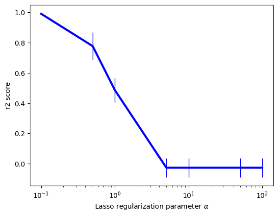

```python
plt.errorbar(alphavals, mean_scores, yerr=2*std_scores, color='blue', linewidth=3, elinewidth=1)
plt.xscale('log')
plt.xlabel('alpha')
plt.ylabel('r2 score')
plt.xlabel(r'Lasso regularization parameter $\alpha$')
```

## 评估模型：sklearn.metrics

- sklearn.metrics包含许多用于评估模型的有用方法。
  - https://scikit-learn.org/stable/modules/model_evaluation.html
- Adjusted Rand Index(ARI)测量两个聚类如何一致。它是衡量我们得出的聚类与真相一致程度的好方法。
  - ARI=1是完美的，ARI=0是随机机会。

## ARI计算

- ARI = (RI - Expected_RI) / (max(RI) - Expected_RI)
- $RI = (a + d)/C_n^2$
  - a：在 Y 和 C 中同属于同一类的样本对数。
  - b：在 Y 中属于不同类，但在C 中属于同一类的样本对数。
  - c：在 Y 中属于同一类，但在 C 中属于不同类的样本对数。
  - d：在 Y 和 C 中都属于不同类的样本对数

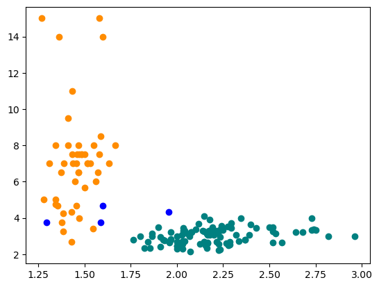

```python
gmm = mixture.GaussianMixture(n_components=3, covariance_type='full')
gmm.fit(R)
labels = gmm.predict(R)
for i in np.unique(labels):
    plt.scatter(sepal_ratio[labels==i], petal_ratio[labels==i], c=colors[i])
```

```python
from sklearn.metrics import adjusted_rand_score
adjusted_rand_score(labels, iris.target)
```

```
0.5312290473980091
```

```python
gmm = mixture.GaussianMixture(n_components=2, covariance_type='full')
gmm.fit(R)
labels = gmm.predict(R)
adjusted_rand_score(labels, iris.target)
```

```
0.5437515388376617
```

## 评估模型：sklearn.metrics

- ROC曲线: 用于评估二分类模型在不同阈值下的性能。
  - 真正率（TPR）：也称为召回率，计算公式为：TPR = TP / (TP + FN)
    - `TP`是真正例的数量（被正确分类为正类的样本数）。
    - `FP`是假负例的数量（被错误分类为负类的正类样本数）。
  - 假正率（FPR）： 其中：FPR = FP / (FP + TN)
    - `FP` 是假正例的数量（被错误分类为正类的负类样本数）。
    - `TN` 是真负例的数量（被正确分类为负类的样本数）。

## 评估模型：sklearn.metrics

- PR（精确率-召回曲线）是通过绘制精确率（Precision）与召回率（Recall）来评估分类模型的性能，尤其是在样本不平衡的情况下更为有效
- 公式
  - 精确率（Precision）： 公式为：TP/(TP+FP)
  - 召回率（Recall）： 召回率也可以与TPR等同于，故简称为recall。

```python
from sklearn.svm import SVC
from sklearn.model_selection import train_test_split
from sklearn.metrics import roc_curve, roc_auc_score
# 加载 Breast Cancer 数据集
cancer = datasets.load_breast_cancer()
X = cancer.data
y = cancer.target

# 将数据划分为训练集和测试集
X_train, X_test, y_train, y_test = train_test_split(X, y, test_size=0.3)

# 创建 SVM 模型并训练
model = SVC(probability=True)  # SVM 模型
model.fit(X_train, y_train)

# 进行预测
y_score = model.predict_proba(X_test)[:, 1]
y_score
```

[output not shown]

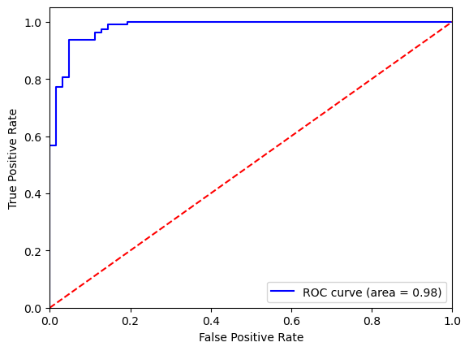

```python
auc_score = roc_auc_score(y_test, y_score)
fpr, tpr, thresholds = roc_curve(y_test, y_score)
plt.figure()
plt.plot(fpr, tpr, color='blue', label='ROC curve (area = {:.2f})'.format(auc_score))
plt.plot([0, 1], [0, 1], color='red', linestyle='--')  # 对角线
plt.xlim([0.0, 1.0]); plt.ylim([0.0, 1.05])
plt.xlabel('False Positive Rate'); plt.ylabel('True Positive Rate')
plt.legend(); plt.show()
```

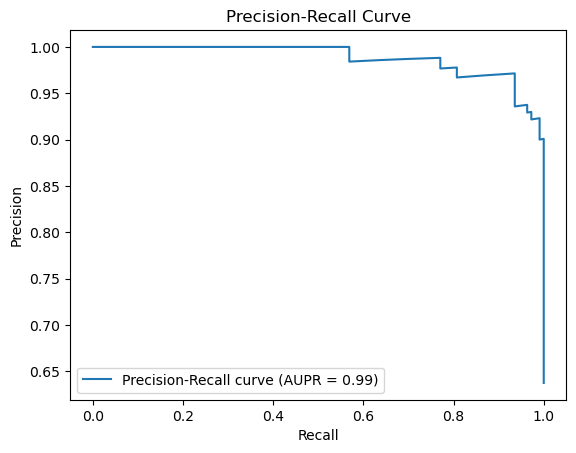

```python
from sklearn.metrics import precision_recall_curve, average_precision_score
precision, recall, _ = precision_recall_curve(y_test, y_score)
aupr = average_precision_score(y_test, y_score)
# 绘制精确率-召回曲线
plt.figure()
plt.plot(recall, precision, label='Precision-Recall curve (AUPR = {:.2f})'.format(aupr))
plt.xlabel('Recall'); plt.ylabel('Precision')
plt.title('Precision-Recall Curve')
plt.legend(); plt.show()
```

## 模型持久性：序列化模型对象

```python
beta = np.zeros(dim)
inds = np.random.choice(np.arange(dim), size=k, replace=False)
beta[inds] = 5*np.random.randn(k)
(n_sample, dim, k) = (200, 500, 10)
X = np.random.randn(n_sample, dim)
y = np.dot(X, beta) + 0.1*np.random.randn(n_sample)

lasso = Lasso(alpha=1)
lasso.fit(X, y)

xtest = np.random.randn(1, dim)
print(lasso.predict(xtest))

import pickle

s = pickle.dumps(lasso)
ytest = np.dot(xtest, beta) + 0.1*np.random.randn(1)
lasso2 = pickle.loads(s)
ypred2 = lasso.predict(xtest)
print(ypred2)
```

```
[9.04203952]
[9.04203952]
```